# Lecture 13: Dummy variables

Economics 326 — Introduction to Econometrics II

Vadim Marmer, UBC

## Interval and ordinal variables

- An **interval** variable is one where the difference between two values is meaningful. Example: “Education” when measured in years. The difference between 12 and 10 years of education is meaningful.
- In some data sets, education is reported as an **ordinal** variable: only the order of its values matters, but the difference between values has no meaning. The following two variables are equivalent:

  $$\text{Education}_{i}=\left\{
  \begin{array}{ll}
  1 & \text{if high-school graduate,} \\
  2 & \text{if college graduate,} \\
  3 & \text{if advanced degree.}
  \end{array}
  \right.$$

  $$\text{Education}_{i}=\left\{
  \begin{array}{ll}
  1 & \text{if high-school graduate,} \\
  10 & \text{if college graduate,} \\
  234 & \text{if advanced degree.}
  \end{array}
  \right.$$

## Categorical variables

- A **categorical** variable has one or more categories, but there is no natural ordering to the categories. Examples: gender, race, marital status, geographic location.
- The following two variables are equivalent:

  $$\text{Gender}_{i}=\left\{
  \begin{array}{ll}
  1 & \text{if observation } i \text{ corresponds to a woman,} \\
  2 & \text{if observation } i \text{ corresponds to a man.}
  \end{array}
  \right.$$

  $$\text{Gender}_{i}=\left\{
  \begin{array}{ll}
  1 & \text{if observation } i \text{ corresponds to a man,} \\
  2 & \text{if observation } i \text{ corresponds to a woman.}
  \end{array}
  \right.$$
- Categorical and ordinal variables are also called **qualitative**.
- Qualitative variables cannot simply be included in a regression because the regression technique assumes that all variables are interval.

## Dummy variables

- A **dummy** variable is a binary zero-one variable that takes on the value one if some condition is satisfied and zero if that condition fails:
  - $\text{Married}_{i}=\left\{ \begin{array}{ll} 1 & \text{if individual } i \text{ is married,} \\ 0 & \text{if individual } i \text{ is not married.} \end{array} \right.$
  - $\text{Unmarried}_{i}=\left\{ \begin{array}{ll} 1 & \text{if individual } i \text{ is not married,} \\ 0 & \text{if individual } i \text{ is married.} \end{array} \right.$
  - Note that $\text{Married}_{i}+\text{Unmarried}_{i}=1$ for all observations $i$.

## Example

- Preview of the `wage1` data from the `wooldridge` package:

  ```r
  library(wooldridge)
  data(wage1)
  head(wage1[, c("wage", "female", "educ", "exper", "tenure")], n = 10)
  ```

  ```
      wage female educ exper tenure
  1   3.10      1   11     2      0
  2   3.24      1   12    22      2
  3   3.00      0   11     2      0
  4   6.00      0    8    44     28
  5   5.30      0   12     7      2
  6   8.75      0   16     9      8
  7  11.25      0   18    15      7
  8   5.00      1   12     5      3
  9   3.60      1   12    26      4
  10 18.18      0   17    22     21
  ```

- In this dataset:
  - `wage` (hourly wage) — **interval** variable.
  - `educ` (years of education), `exper` (years of experience), `tenure` (years at current firm) — **interval** variables.
  - `female` (1 if woman, 0 if man) — **dummy** (categorical) variable.

## Single dummy independent variable

- Consider the following regression:

  $$\text{Wage}_{i}=\beta_{0}+\delta_{0}\text{Female}_{i}+\beta_{1}\text{Educ}_{i}+\beta_{3}\text{Exper}_{i}+\beta_{4}\text{Tenure}_{i}+U_{i},$$

  and assume that $\mathrm{E}\left[U_{i} \mid \text{Female}_{i}, \text{Educ}_{i}, \text{Exper}_{i}, \text{Tenure}_{i}\right]=0.$
- Here, tenure refers to the number of years the worker has been employed at their current firm.
- If observation $i$ corresponds to a woman, $\text{Female}_{i}=1$, and

  $$\begin{aligned}
  &\mathrm{E}\left[\text{Wage}_{i} \mid \text{Female}_{i}=1, \text{Educ}_{i}, \text{Exper}_{i}, \text{Tenure}_{i}\right] \\
  &= \beta_{0}+{\color{red}\delta_{0}}+\beta_{1}\text{Educ}_{i}+\beta_{3}\text{Exper}_{i}+\beta_{4}\text{Tenure}_{i}.
  \end{aligned}$$
- If observation $i$ corresponds to a man, $\text{Female}_{i}=0$, and

  $$\begin{aligned}
  &\mathrm{E}\left[\text{Wage}_{i} \mid \text{Female}_{i}=0, \text{Educ}_{i}, \text{Exper}_{i}, \text{Tenure}_{i}\right] \\
  &= \beta_{0}+\beta_{1}\text{Educ}_{i}+\beta_{3}\text{Exper}_{i}+\beta_{4}\text{Tenure}_{i}.
  \end{aligned}$$
- Thus,

  $$\begin{aligned}
  {\color{red}\delta_{0}} &= \mathrm{E}\left[\text{Wage}_{i} \mid \text{Female}_{i}=1, \text{Educ}_{i}, \text{Exper}_{i}, \text{Tenure}_{i}\right] \\
  &\quad - \mathrm{E}\left[\text{Wage}_{i} \mid \text{Female}_{i}=0, \text{Educ}_{i}, \text{Exper}_{i}, \text{Tenure}_{i}\right].
  \end{aligned}$$

## Intercept shift

- The model:

  $$\text{Wage}_{i}=\beta_{0}+\delta_{0}\text{Female}_{i}+\beta_{1}\text{Educ}_{i}+\beta_{3}\text{Exper}_{i}+\beta_{4}\text{Tenure}_{i}+U_{i}.$$
- For men ($\text{Female}_{i}=0$):

  $$\text{Wage}_{i}^M=\beta_{0}+\beta_{1}\text{Educ}_{i}+\beta_{3}\text{Exper}_{i}+\beta_{4}\text{Tenure}_{i}+U_{i}.$$
- For women ($\text{Female}_{i}=1$):

  $$\text{Wage}_{i}^F=\left(\beta_{0}+\delta_{0}\right)+\beta_{1}\text{Educ}_{i}+\beta_{3}\text{Exper}_{i}+\beta_{4}\text{Tenure}_{i}+U_{i}.$$
- In this case, men play the role of the **base** group.
- $\delta_{0}$ measures the wage difference relative to the base group.

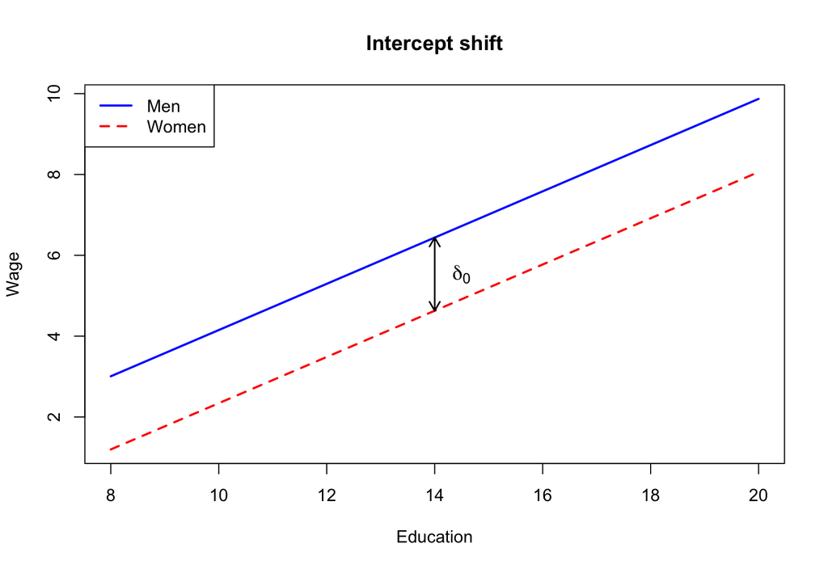

## Example

- Estimated equation:

  $$\begin{aligned}
  \widehat{\text{Wage}}_{i} &= \underset{(0.72)}{-1.57}\, {\color{red}\underset{(0.26)}{-1.81}}\, \text{Female}_{i} + \underset{(0.049)}{0.572}\, \text{Educ}_{i} \\
  &\quad + \underset{(0.012)}{0.025}\, \text{Exper}_{i} + \underset{(0.021)}{0.141}\, \text{Tenure}_{i}.
  \end{aligned}$$
- The dependent variable is the wage per hour.
- $\hat{\delta}_{0}=-1.81$ implies that a woman earns $1.81 less per hour than a man with the same level of education, experience, and tenure. (These are 1976 wages.)
- The difference is also statistically significant.

## Log dependent variable

- The model:

  $$\ln\left(\text{Wage}_{i}\right)=\beta_{0}+\delta_{0}\text{Female}_{i}+\beta_{1}\text{Educ}_{i}+\beta_{3}\text{Exper}_{i}+\beta_{4}\text{Tenure}_{i}+U_{i}.$$
- In this case,

  $$\begin{aligned}
  \delta_{0} &= \ln\left(\text{Wage}^{F}\right)-\ln\left(\text{Wage}^{M}\right) \\
  &= \ln\left(\frac{\text{Wage}^{F}}{\text{Wage}^{M}}\right) \\
  &= \ln\left(\frac{\text{Wage}^{M}+\left(\text{Wage}^{F}-\text{Wage}^{M}\right)}{\text{Wage}^{M}}\right) \\
  &= \ln\left(1+\frac{\text{Wage}^{F}-\text{Wage}^{M}}{\text{Wage}^{M}}\right) \\
  &\approx \frac{\text{Wage}^{F}-\text{Wage}^{M}}{\text{Wage}^{M}}.
  \end{aligned}$$
- When the dependent variable is in the log form, $\delta_{0}$ has a **percentage** interpretation.

## Example

- Estimated equation:

  $$\begin{aligned}
  \widehat{\ln\left(\text{Wage}_{i}\right)} &= \underset{(0.099)}{0.417}\, {\color{red}\mathbin{-}\underset{(0.036)}{0.297}}\, \text{Female}_{i} + \underset{(0.007)}{0.080}\, \text{Educ}_{i} \\
  &\quad + \underset{(0.005)}{0.029}\, \text{Exper}_{i} - \underset{(0.00010)}{0.00058}\, \text{Exper}_{i}^{2} \\
  &\quad + \underset{(0.007)}{0.032}\, \text{Tenure}_{i} - \underset{(0.00023)}{0.00059}\, \text{Tenure}_{i}^{2}.
  \end{aligned}$$
- $\hat{\delta}_{0}=-0.297$ implies that a woman earns 29.7% less than a man with the same level of education, experience, and tenure.

## Changing the base group

- Instead of

  $$\begin{aligned}
  \ln\left(\text{Wage}_{i}\right)
  &= {\color{blue}\beta_{0}}+{\color{red}\delta_{0}}\text{Female}_{i}+{\color{blue}\beta_{1}}\text{Educ}_{i} \\
  &\quad + {\color{blue}\beta_{3}}\text{Exper}_{i}+{\color{blue}\beta_{4}}\text{Tenure}_{i}+U_{i},
  \end{aligned}$$

  consider:

  $$\begin{aligned}
  \ln\left(\text{Wage}_{i}\right)
  &= {\color{blue}\theta_{0}}+{\color{red}\gamma_{0}}\text{Male}_{i}+{\color{blue}\theta_{1}}\text{Educ}_{i} \\
  &\quad + {\color{blue}\theta_{3}}\text{Exper}_{i}+{\color{blue}\theta_{4}}\text{Tenure}_{i}+U_{i}.
  \end{aligned}$$
- Since $\text{Male}_{i}=1-\text{Female}_{i},$

  $$\begin{aligned}
  \ln\left(\text{Wage}_{i}\right)
  &= {\color{blue}\theta_{0}}+{\color{red}\gamma_{0}}\text{Male}_{i}+{\color{blue}\theta_{1}}\text{Educ}_{i} \\
  &\quad + {\color{blue}\theta_{3}}\text{Exper}_{i}+{\color{blue}\theta_{4}}\text{Tenure}_{i}+U_{i} \\
  &= {\color{blue}\theta_{0}}+{\color{red}\gamma_{0}}\left(1-\text{Female}_{i}\right)+{\color{blue}\theta_{1}}\text{Educ}_{i} \\
  &\quad + {\color{blue}\theta_{3}}\text{Exper}_{i}+{\color{blue}\theta_{4}}\text{Tenure}_{i}+U_{i} \\
  &= \left({\color{blue}\theta_{0}}+{\color{red}\gamma_{0}}\right)-{\color{red}\gamma_{0}}\text{Female}_{i}+{\color{blue}\theta_{1}}\text{Educ}_{i} \\
  &\quad + {\color{blue}\theta_{3}}\text{Exper}_{i}+{\color{blue}\theta_{4}}\text{Tenure}_{i}+U_{i}.
  \end{aligned}$$
- We conclude that ${\color{red}\delta_{0}=-\gamma_{0}},$ ${\color{blue}\beta_{0}=\theta_{0}+\gamma_{0}},$ ${\color{blue}\beta_{1}=\theta_{1}},$ etc.:

  $$\begin{aligned}
  \ln\left(\text{Wage}_{i}\right)
  &= \left({\color{blue}\beta_{0}}+{\color{red}\delta_{0}}\right)-{\color{red}\delta_{0}}\text{Male}_{i}+{\color{blue}\beta_{1}}\text{Educ}_{i} \\
  &\quad + {\color{blue}\beta_{3}}\text{Exper}_{i}+{\color{blue}\beta_{4}}\text{Tenure}_{i}+U_{i}.
  \end{aligned}$$
- Thus, changing the base group has no effect on the conclusions.
- In this dataset, gender is recorded as a binary variable (female/male). The dummy variable approach shown here applies to any binary grouping.

## Dummy variable trap

- Consider the equation:

  $$\begin{aligned}
  \ln\left(\text{Wage}_{i}\right) &= \beta_{0}+\delta_{0}\text{Female}_{i}+\gamma_{0}\text{Male}_{i} \\
  &\quad +\beta_{1}\text{Educ}_{i}+\beta_{3}\text{Exper}_{i}+\beta_{4}\text{Tenure}_{i}+U_{i}.
  \end{aligned}$$
- Recall that the intercept is a regressor that takes the value one for all observations.
- In this dataset, $\text{Female}_{i}+\text{Male}_{i}=1$ for all observations $i$, so we have **perfect multicollinearity**. Such an equation cannot be estimated.
- **One cannot include an intercept and dummies for all the groups!**

## Dummy variable trap

- One of the dummies has to be omitted and the corresponding group becomes the **base** group:
  - Men are the base group: $\ln\left(\text{Wage}_{i}\right)=\beta_{0}+\delta_{0}\text{Female}_{i}+\beta_{1}\text{Educ}_{i}+\beta_{3}\text{Exper}_{i}+\beta_{4}\text{Tenure}_{i}+U_{i}.$
  - Women are the base group: $\ln\left(\text{Wage}_{i}\right)=\theta_{0}+\gamma_{0}\text{Male}_{i}+\beta_{1}\text{Educ}_{i}+\beta_{3}\text{Exper}_{i}+\beta_{4}\text{Tenure}_{i}+U_{i}.$
- Alternatively, one can include both dummies **without** the intercept:

  $\ln\left(\text{Wage}_{i}\right)=\pi_{0}\text{Female}_{i}+\pi_{1}\text{Male}_{i}+\beta_{1}\text{Educ}_{i}+\beta_{3}\text{Exper}_{i}+\beta_{4}\text{Tenure}_{i}+U_{i}.$
  - In R, a regression without an intercept can be estimated by adding `+ 0` or `- 1` to the formula:

    ```r
    lm(Y ~ X + 0)
    ```

    or equivalently:

    ```r
    lm(Y ~ X - 1)
    ```

  - The coefficients on the dummy variables lose the difference interpretation.

## Slope changes and interactions

- We can also allow the returns to education to be different for men and women:

  $$\begin{aligned}
  \ln\left(\text{Wage}_{i}\right) &= \beta_{0}+\delta_{0}\text{Female}_{i}+\beta_{1}\text{Educ}_{i}+\delta_{1}\left(\text{Female}_{i}\cdot \text{Educ}_{i}\right) \\
  &\quad +\beta_{3}\text{Exper}_{i}+\beta_{4}\text{Tenure}_{i}+U_{i}.
  \end{aligned}$$
- The variable $\left(\text{Female}_{i}\cdot \text{Educ}_{i}\right)$ is called an **interaction**.
- The equation for men ($\text{Female}_{i}=0$):

  $$\ln\left(\text{Wage}_{i}^{M}\right)=\beta_{0}+\beta_{1}\text{Educ}_{i}+\beta_{3}\text{Exper}_{i}+\beta_{4}\text{Tenure}_{i}+U_{i}.$$
- The equation for women ($\text{Female}_{i}=1$):

  $$\begin{aligned}
  \ln\left(\text{Wage}_{i}^{F}\right) &= \left(\beta_{0}+\delta_{0}\right)+\left(\beta_{1}+\delta_{1}\right)\text{Educ}_{i} \\
  &\quad +\beta_{3}\text{Exper}_{i}+\beta_{4}\text{Tenure}_{i}+U_{i}.
  \end{aligned}$$
- $\delta_{1}$ can be interpreted as the difference in the return to education between women and men (the base group) after controlling for experience and tenure.

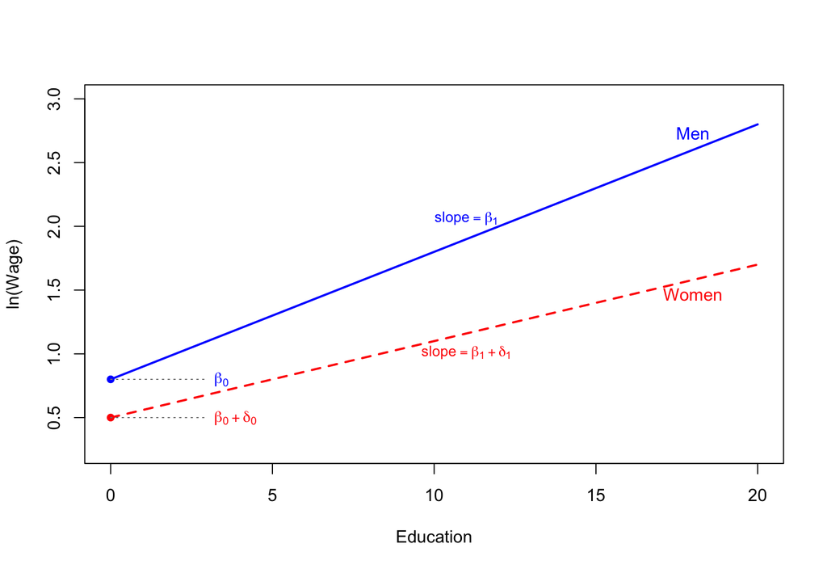

## Example

- Estimated equation:

  $$\begin{aligned}
  \widehat{\ln\left(\text{Wage}_{i}\right)}
  &= \underset{(0.119)}{0.389} - \underset{(0.168)}{0.227}\, \text{Female}_{i} \\
  &\quad + \underset{(0.008)}{0.082}\, \text{Educ}_{i} {\color{red}-\underset{(0.0131)}{0.0056}}\, \text{Female}_{i}\cdot \text{Educ}_{i} \\
  &\quad + \underset{(0.005)}{0.029}\, \text{Exper}_{i} - \underset{(0.00011)}{0.00058}\, \text{Exper}_{i}^{2} \\
  &\quad + \underset{(0.007)}{0.032}\, \text{Tenure}_{i} - \underset{(0.00024)}{0.00059}\, \text{Tenure}_{i}^{2}.
  \end{aligned}$$
- $\hat{\delta}_{1}=-0.0056$, suggesting that the return to education for women is 0.56 percentage points less than for men; however, this difference is not statistically significant. We cannot reject the hypothesis that the return to education is the same for men and women.

## Multiple categories

- In the previous examples, $\text{Educ}$ was a quantitative variable: years of education.
- Suppose now that instead the education variable is **ordinal**:

  $$\text{Education}_{i} = \left\{
  \begin{array}{ll}
  1 & \text{if high-school dropout,} \\
  2 & \text{if high-school graduate,} \\
  3 & \text{if some college,} \\
  4 & \text{if college graduate,} \\
  5 & \text{if advanced degree.}
  \end{array}
  \right.$$
- Only the order is important, and there is no meaning to the **distance** between the values.
- Adding such a variable to the regression will give a meaningless result.

## Multiple categories

- Recall the ordinal education variable:

  $$\text{Education}_{i} = \left\{
  \begin{array}{ll}
  1 & \text{if high-school dropout,} \\
  2 & \text{if high-school graduate,} \\
  3 & \text{if some college,} \\
  4 & \text{if college graduate,} \\
  5 & \text{if advanced degree.}
  \end{array}
  \right.$$
- Define 5 new dummy variables:

  $$\begin{aligned}
  E_{1,i} &= \begin{cases} 1 & \text{if high-school dropout,} \\ 0 & \text{otherwise.} \end{cases} \\
  E_{2,i} &= \begin{cases} 1 & \text{if high-school graduate,} \\ 0 & \text{otherwise.} \end{cases} \\
  E_{3,i} &= \begin{cases} 1 & \text{if some college,} \\ 0 & \text{otherwise.} \end{cases} \\
  E_{4,i} &= \begin{cases} 1 & \text{if college graduate,} \\ 0 & \text{otherwise.} \end{cases} \\
  E_{5,i} &= \begin{cases} 1 & \text{if advanced degree,} \\ 0 & \text{otherwise.} \end{cases}
  \end{aligned}$$
- To avoid the dummy variable trap, one of the dummies has to be omitted:

  $$\begin{aligned}
  \text{Wage}_{i}
  &= \beta_{0}+\delta_{0}\text{Female}_{i}+\delta_{2}E_{2,i}+\delta_{3}E_{3,i} \\
  &\quad + \delta_{4}E_{4,i}+\delta_{5}E_{5,i}+\text{Other Factors}
  \end{aligned}$$
- Group 1 (high-school dropout) becomes the base group.
- $\delta_{2}$ measures the wage difference between high-school graduates and high-school dropouts.
- $\delta_{3}$ measures the wage difference between individuals with some college education and high-school dropouts.

## Comparing consecutive groups

- The previous definitions compare each group to the **base** group (high-school dropouts). Alternatively, we can define dummies that compare each group to the **previous** one:

  $$\begin{aligned}
  D_{2,i} &= \begin{cases} 1 & \text{if high-school graduate or higher,} \\ 0 & \text{otherwise.} \end{cases} \\
  D_{3,i} &= \begin{cases} 1 & \text{if some college or higher,} \\ 0 & \text{otherwise.} \end{cases} \\
  D_{4,i} &= \begin{cases} 1 & \text{if college graduate or higher,} \\ 0 & \text{otherwise.} \end{cases} \\
  D_{5,i} &= \begin{cases} 1 & \text{if advanced degree,} \\ 0 & \text{otherwise.} \end{cases}
  \end{aligned}$$
- The model:

  $$\begin{aligned}
  \text{Wage}_{i}
  &= \beta_{0}+\delta_{0}\text{Female}_{i}+\gamma_{2}D_{2,i}+\gamma_{3}D_{3,i} \\
  &\quad + \gamma_{4}D_{4,i}+\gamma_{5}D_{5,i}+\text{Other Factors}
  \end{aligned}$$
- $\gamma_{2}$ measures the wage difference between high-school graduates and high-school dropouts.
- $\gamma_{3}$ measures the wage difference between individuals with some college and high-school graduates.
- $\gamma_{4}$ measures the wage difference between college graduates and individuals with some college.
- $\gamma_{5}$ measures the wage difference between individuals with advanced degrees and college graduates.